# Class 12: Difference in Differences

Data come from: [Grumbach, J. M. (2023). Laboratories of democratic backsliding. *American Political Science Review*, *117*(3), 967-984](https://www-cambridge-org.proxy-um.researchport.umd.edu/core/journals/american-political-science-review/article/laboratories-of-democratic-backsliding/0742F08306EFDD8612539F089853E4FE). ([Dataverse](https://dataverse.harvard.edu/dataset.xhtml?persistentId=doi:10.7910/DVN/JNV3XO))

# Data import and libraries

```r
library(tidyverse)
library(fixest)
library(did)

if(!file.exists("grumbach.rds")){
  download.file('https://github.com/Neilblund/GVPT728_Winter24/raw/refs/heads/main/Additional%20Code%20and%20Data/grumbach.rds',
                destfile='grumbach.rds',
                mode='wb'
                )


}
data<-readRDS('grumbach.rds')
```

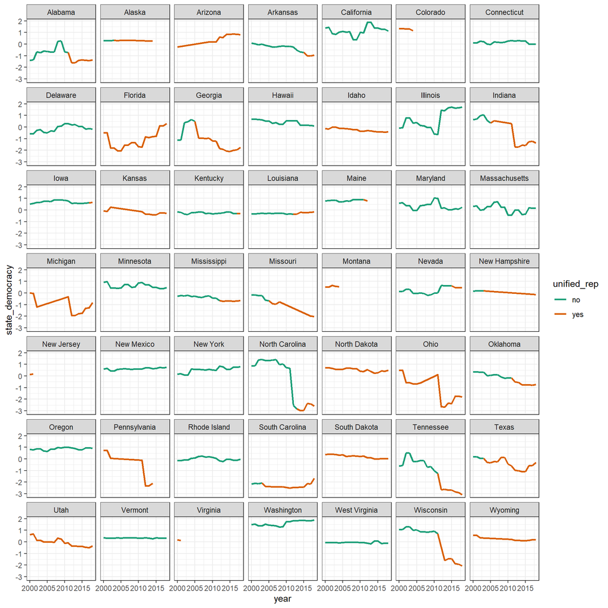

```r
data|>
  mutate(unified_rep =factor(unified_rep, labels=c("no", "yes")))|>
ggplot( aes(x=year, y=state_democracy,
                 group=state, color=unified_rep))  +
  geom_line(lwd=1) +
  facet_wrap(~state)+
  theme_bw() +
  scale_color_brewer(palette='Dark2')
```

# Staggered Difference in Differences

The simplest approach here is a two-way fixed effects model, but since we’ve got multiple time periods and cases with staggered entry, this isn’t going to give us the right estimates if there are heterogeneous treatment effects over time or across cases.

Instead, we can the using the [`did`](https://bcallaway11.github.io/did/index.html) package to estimate an average effect. The basic idea here is to estimate multiple different “difference-in-differences” coefficients for each time period and group and then calculate a weighted average based on the number of observations in each group.

To make this work, we need to put the data into a compatible format. Using the `att_gt` function requires that we specify:

- `idname` a numeric ID for each group (this will just be a numeric ID for each state)
- `tname` a time period indicator (this should just be a sequence from 1 to N for each year)
- `gname` a variable that indicates, for each observation, the value of `tname` when they first received the treatment. (in our case, it should be the period when the state first came under unified Republican control, and it should be a zero for all cases where this never occurred)

```r
did_fmt<-data|>
  group_by(state)|>
  # convert year to time periods
  mutate(period = year - 1999,
  # add variable for ever under unified Rep control
         ever_rep = any(unified_rep==1),
  # add the first year of republican unified control
         first_r_year = case_when(ever_rep ~ min(period[which(unified_rep==1)]),
                                  .default = 0)
         )|>
  ungroup()|>
  # assign numeric state IDs
  mutate(id = as.numeric(factor(state)))
```

The output from this function contains a long list of estimated group/time level effects, we’ll generally want to aggregate these using one of the methods proposed by the authors.

```r
att <- att_gt(yname = "state_democracy",
              tname = "period",
              idname = "id",
              gname = "first_r_year",
             # xformula = ~x # Would add controls here...
              allow_unbalanced_panel = T,
              data = did_fmt
)


att|>
  tidy()|>
  arrange(time)|>
  slice_head(n =5)
```

| term | group | time | estimate | std.error | conf.low | conf.high | point.conf.low | point.conf.high |
| --- | --- | --- | --- | --- | --- | --- | --- | --- |
| ATT(4,2) | 4 | 2 | 0.005906773 | 0.012879419 | -0.02953946 | 0.04135301 | -0.019336424 | 0.03114997 |
| ATT(6,2) | 6 | 2 | -0.003780958 | 0.008209436 | -0.02637465 | 0.01881273 | -0.019871156 | 0.01230924 |
| ATT(12,2) | 12 | 2 | 0.006692367 | 0.008645998 | -0.01710281 | 0.03048755 | -0.010253478 | 0.02363821 |
| ATT(13,2) | 13 | 2 | 0.009427052 | 0.017891557 | -0.03981340 | 0.05866750 | -0.025639757 | 0.04449386 |
| ATT(14,2) | 14 | 2 | 0.004977972 | 0.006044694 | -0.01165800 | 0.02161395 | -0.006869411 | 0.01682535 |

To get a single average estimated effect, we can use `type="simple"`. This represents a weighted average of all of the group x time-specific coefficients.

```r
att_simple <- aggte(att, type = "simple")
att_simple
```

```
Call:
aggte(MP = att, type = "simple")

Reference: Callaway, Brantly and Pedro H.C. Sant'Anna.  "Difference-in-Differences with Multiple Time Periods." Journal of Econometrics, Vol. 225, No. 2, pp. 200-230, 2021. <https://doi.org/10.1016/j.jeconom.2020.12.001>, <https://arxiv.org/abs/1803.09015>

     ATT    Std. Error     [ 95%  Conf. Int.]
 -0.9725        0.1894    -1.3438     -0.6012 *


---
Signif. codes: `*' confidence band does not cover 0

Control Group:  Never Treated,  Anticipation Periods:  0
Estimation Method:  Doubly Robust
```

Alternatively, we can get an average effect for each group (this is the default setting)

```r
att_group <- aggte(att, type = "group")
att_group|>
  tidy()
```

| type | term | group | estimate | std.error | conf.low | conf.high | point.conf.low | point.conf.high |
| --- | --- | --- | --- | --- | --- | --- | --- | --- |
| group | ATT(Average) | Average | -0.81574893 | 0.22570261 | -1.25811791 | -0.37337995 | -1.25811791 | -0.37337995 |
| group | ATT(4) | 4 | -0.72578451 | 0.17710172 | -1.13723874 | -0.31433028 | -1.07289751 | -0.37867151 |
| group | ATT(6) | 6 | -1.53662888 | 0.33879078 | -2.32372962 | -0.74952813 | -2.20064661 | -0.87261114 |
| group | ATT(12) | 12 | -1.45354616 | 0.37392551 | -2.32227419 | -0.58481814 | -2.18642669 | -0.72066563 |
| group | ATT(13) | 13 | -0.15652547 | 0.22737337 | -0.68477404 | 0.37172310 | -0.60216908 | 0.28911814 |
| group | ATT(14) | 14 | -0.05519286 | 0.04481798 | -0.15931689 | 0.04893117 | -0.14303448 | 0.03264876 |
| group | ATT(16) | 16 | -0.18970090 | 0.05924890 | -0.32735178 | -0.05205002 | -0.30582660 | -0.07357520 |
| group | ATT(18) | 18 | 0.01458571 | 0.01580893 | -0.02214263 | 0.05131404 | -0.01639923 | 0.04557064 |

Finally, we can estimate a dynamic treatment effect that estimates the effect sizes before and after treatment. This is one way to bolster the argument for parallel trends: if the parallel trends assumption holds, then we expect the “leads” of the treatment (red color) to be 0.

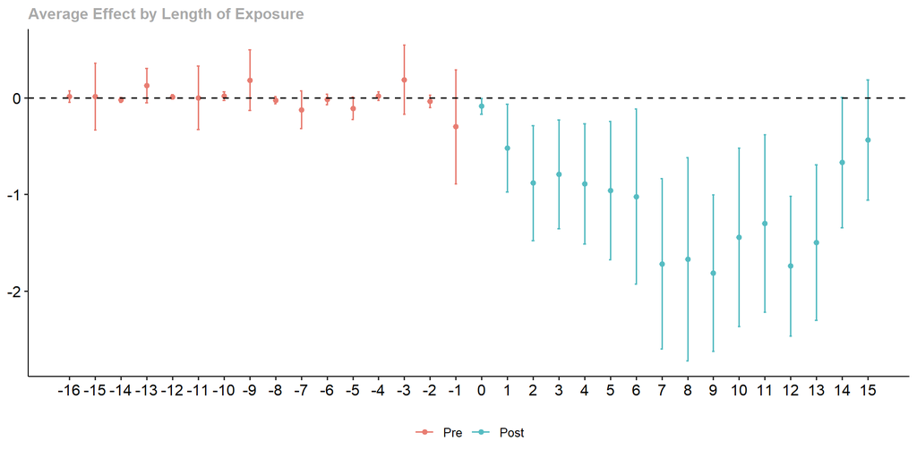

```r
att_dynamic<-aggte(att, type = "dynamic")

ggdid(att_dynamic)
```